# Prepare Haplotypes in the GREB1L Region for Further Analyses

Eric C. Anderson

Last Updated: 2020-05-14

The goal here is to infer haplotypes in the GREB1L region to be used in later analyses. We use a small portion of the VCF that is saved in this repository in `data/greb1l-ish-region.vcf.gz`

# Packages and paths

```r
library(tidyverse)
library(vcfR)

dir.create("outputs/004", recursive = TRUE, showWarnings = FALSE)
dir.create("intermediates/004", recursive = TRUE, showWarnings = FALSE)
```

# Manipulating the VCF file

## Get sample names and prepare a file to reheader the vcf

```r
samples <- read_csv("data/wgs-chinook-samples.csv") %>%
  mutate(newname = paste0(Population, "-", NMFS_DNA_ID)) %>%
  mutate(newname = str_replace_all(newname, " +", "_"))

new_names <- samples %>%
  select(vcf_name, newname)

write_tsv(new_names, "intermediates/004/new_names_for_vcf.txt", col_names = FALSE)
```

## Use bcftools to reheader the file with new sample names

This VCF we are reheadering is about 5 Mb around the GREB1L RoSA.

```bash
bcftools reheader -s intermediates/004/new_names_for_vcf.txt data/greb1l-ish-region.vcf.gz > intermediates/004/fish_for_tree.vcf.gz
```

## Filter sites

We will filter sites with vcftools. Criteria:

1. biallelic (this just drops 1000 or so out of 49,000. Seems reasonable).
2. Genotype call in the vcf for more then 40% of the individuals.
3. Minor allele freq > 0.05

```bash
vcftools --gzvcf intermediates/004/fish_for_tree.vcf.gz --min-alleles 2 --max-alleles 2 --max-missing 0.4 --maf 0.05 --out intermediates/004/greb1l-ish-filtered --recode
```

```
##
## VCFtools - v0.1.12b
## (C) Adam Auton and Anthony Marcketta 2009
##
## Parameters as interpreted:
##  --gzvcf intermediates/004/fish_for_tree.vcf.gz
##  --maf 0.05
##  --max-alleles 2
##  --min-alleles 2
##  --max-missing 0.4
##  --out intermediates/004/greb1l-ish-filtered
##  --recode
##
## Using zlib version: 1.2.5
## After filtering, kept 160 out of 160 Individuals
## Outputting VCF file...
## After filtering, kept 25539 out of a possible 49264 Sites
## Run Time = 9.00 seconds
```

## Attach ancestral alleles from coho

Now we attach the ancestral alleles to the vcf and filter out those that don’t have known ancestral states:

```bash
echo '##INFO=<ID=AA,Number=1,Type=String,Description="Ancestral allele">' > aa.hdr

bcftools +fill-from-fasta intermediates/004/greb1l-ish-filtered.recode.vcf -- -c AA -f stored_results/001/NC_037124.1_coho.fna.gz -h aa.hdr  > intermediates/004/almost-ready-for-imputation.vcf
rm aa.hdr
```

## Extract Read Depth Information for those Genotypes

We want to get the read depths so we can look at that information later in the plots. So let’s get it:

```r
rfi <- read.vcfR("intermediates/004/almost-ready-for-imputation.vcf")
```

[output not shown]

```r
rfi_depths <- vcfR2tidy(rfi)$gt %>%
  select(Indiv, POS, gt_DP) %>%
  mutate(DP = ifelse(is.na(gt_DP), 0, gt_DP)) %>%
  select(-gt_DP)
```

Now, while we are at it, let’s look at the average per-site depth for different fish in there:

```r
dp_means <- rfi_depths %>%
  group_by(Indiv) %>%
  summarise(mean_depth = mean(DP)) %>%
  arrange(mean_depth)
dp_means
```

| Indiv | mean_depth |
| --- | --- |
| Salmon_River_Spring-T145120 | 0.002310192 |
| Salmon_River_Spring-T145111 | 0.002349348 |
| Salmon_River_Fall-T144770 | 0.008849211 |
| Salmon_River_Fall-T144774 | 0.011433494 |
| Salmon_River_Fall-T144782 | 0.021535691 |
| Salmon_River_Spring-T145114 | 0.039547359 |
| Salmon_River_Spring-T145123 | 0.045929754 |
| Salmon_River_Spring-T145119 | 0.063197463 |
| Salmon_River_Spring-T145125 | 0.065938369 |
| Salmon_River_Spring-T145117 | 0.106347155 |

[output cut: 150 more lines]

And now look at that:

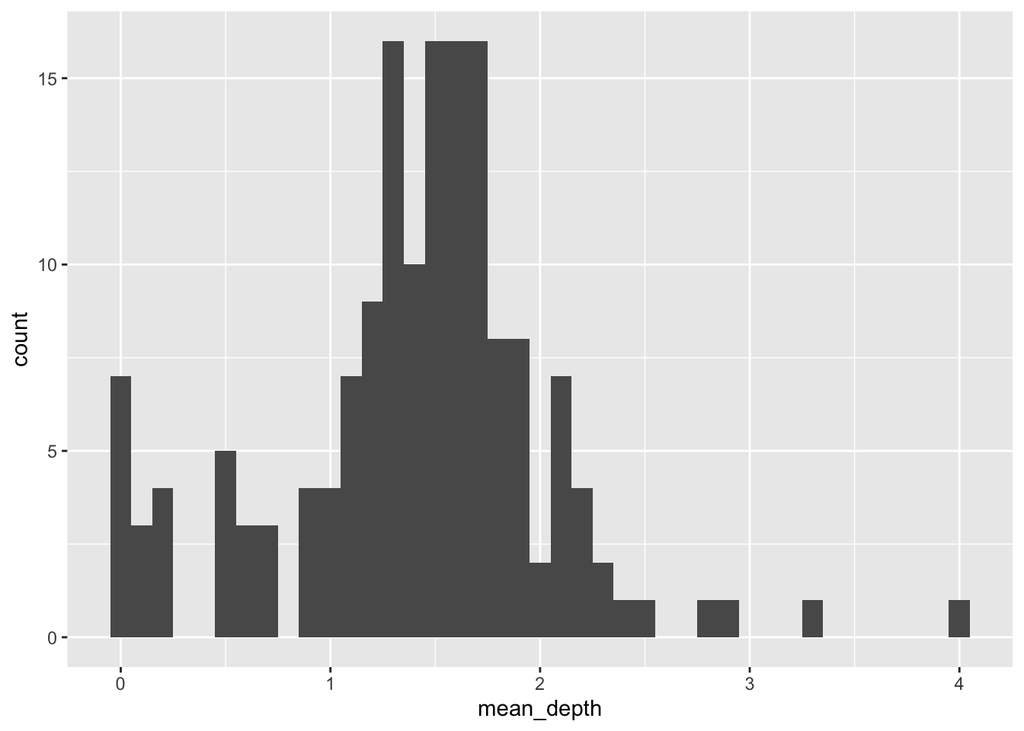

```r
ggplot(dp_means, aes(x = mean_depth)) +
  geom_histogram(binwidth = 0.1)
```

We are going to toss anyone with average read depth less than 0.45 as that is a good cutoff that gets all the really poor samples. Sadly, these are mostly fish that were sampled as carcasses in the Salmon River, but we want to keep our data clean for haplotyping, so we will drop those individuals at this stage.

```r
dp_means %>%
  filter(mean_depth > 0.45) %>%
  .$Indiv %>%
  cat(sep = "\n", file = "intermediates/004/suff-read-depth-inds.txt")
```

Now, we grab them

```bash
vcftools --vcf intermediates/004/almost-ready-for-imputation.vcf --keep intermediates/004/suff-read-depth-inds.txt --out intermediates/004/ready-for-imputation-suff-rd --recode

cp intermediates/004/ready-for-imputation-suff-rd.recode.vcf intermediates/004/ready-for-imputation.vcf
```

```
##
## VCFtools - v0.1.12b
## (C) Adam Auton and Anthony Marcketta 2009
##
## Parameters as interpreted:
##  --vcf intermediates/004/almost-ready-for-imputation.vcf
##  --keep intermediates/004/suff-read-depth-inds.txt
##  --out intermediates/004/ready-for-imputation-suff-rd
##  --recode
##
## Keeping individuals in 'keep' list
## After filtering, kept 146 out of 160 Individuals
## Outputting VCF file...
## After filtering, kept 25539 out of a possible 25539 Sites
## Run Time = 8.00 seconds
```

# Impute and phase with BEAGLE

Others will have to adjust their paths to BEAGLE. First the imputation

```bash
source script/java-jar-paths.sh

echo "Using Beagle jar at: $BEAGLE"
java -jar $BEAGLE gl=intermediates/004/ready-for-imputation.vcf  out=intermediates/004/greb1l-imputed > intermediates/004/beagle-impute-stdout.txt
```

```
## Using Beagle jar at: /Users/eriq/Documents/others_code/BEAGLE_4.1/beagle.27Jan18.7e1.jar
```

And then the haplotype phasing.

```bash
source script/java-jar-paths.sh

java -jar $BEAGLE gt=intermediates/004/greb1l-imputed.vcf.gz out=intermediates/004/greb1l-imp-phased > intermediates/004/beagle-phase-stdout.txt
```

And after that, we reattach the ancestral states:

```bash
# gotta do this cuz BEAGLE doesn't put the contig name in there
tabix -f intermediates/004/greb1l-imp-phased.vcf.gz

echo '##INFO=<ID=AA,Number=1,Type=String,Description="Ancestral allele">' > aa.hdr

bcftools +fill-from-fasta intermediates/004/greb1l-imp-phased.vcf.gz -- -c AA -f stored_results/001/NC_037124.1_coho.fna.gz -h aa.hdr  > intermediates/004/greb1l-imp-phased-with-anc.vcf
rm aa.hdr
```

OK, now we have `intermediates/004/greb1l-imp-phased-with-anc.vcf` which is a VCF file of phased haplotypes along with an ancestral allele (AA) tag in the INFO.

# Further Processing

From here, forward, we will be using those variants in R, so we will output them in rds format for future use, along with the read-depth information.

Read in the haplotype data:

```r
V <- "intermediates/004/greb1l-imp-phased-with-anc.vcf"
haps <- ecaRbioinf::vcf_haplos2tidy(V, Anc = "Coho")
```

[output not shown]

```r
# if we kept sites that don't have an ancestral allele from Coho, mark those as NA so the derived allelic states will be NA too.
haps$fix <- haps$fix %>%
  mutate(AA = ifelse(AA == "N", NA, AA))
```

First, straighten out the haplotype names, etc.

```r
big_haps <- haps$tidy %>%
  filter(Indiv != "Coho") %>%
  left_join(haps$avd, by = c("ChromKey", "POS", "Indiv", "haplo")) %>%
  mutate(haplo_name = paste0(Indiv, "-", haplo)) %>%
  left_join(rfi_depths, by = c("POS", "Indiv")) %>% # add the read depth information in there
  mutate(
    pop = str_replace_all(Indiv, "(_Spring|_Late_Fall|_Fall|_Winter).*$", ""), # add useful columns of meta data
    ecotype = str_match(Indiv, "(Spring|Late_Fall|Fall|Winter)")[, 1],
    lineage = ifelse(pop %in% c("Salmon_River", "Trinity_River_Hatchery"), "Klamath", "Sacto")
  )
```

Now, to color everything by the allele that is most common amongst springers, we recode a column of alleles as S (for spring) and F (for fall)

```r
spring_ones <- big_haps %>%
  filter(ecotype == "Spring") %>%
  group_by(POS, allele) %>%
  summarise(freq = n()) %>%
  filter(rank(-freq, ties = "first") == 1) %>%
  rename(spring_allele = allele) %>%
  ungroup()

big_haps <- big_haps %>%
  left_join(spring_ones, by = "POS") %>%
  mutate(alle2 = ifelse(allele == spring_allele, "S", "F"))
```

And now we need to Join REF and ALT onto that. Down the road, it will be important to know which allele was REF and which was ALT. I’m going to stick that information into `big_haps2` so that we have it all, easily:

```r
big_haps2 <- haps$fix %>%
  select(POS, REF, ALT) %>%
  left_join(big_haps, ., by = "POS") %>%
  select(ChromKey, POS, REF, ALT, everything())
```

# Insert Variation from the Johnson Creek fish (Narum assembly)

```r
# first, get the distinct positions in big_haps2
bh2d <- big_haps2 %>%
  select(ChromKey, POS, REF, ALT, spring_allele) %>%
  distinct()

# get narvars and nar_refms (Johnson Creek Variants) from 003
load("outputs/003/greb_region_narum_variants.rda")

# now, we are going to only focus on the variants called in the broader
# data set, so we will left_join stuff onto those.
all_together <- bh2d %>%
  left_join(., narvars) %>%
  left_join(., nar_refms)

# and now we create a data frame that includes all the information for
# the interior columbia individual, as if it were part of our data set.
# We do this by choosing its alleles, and naming it, etc.
jc_fish <- all_together %>%
  mutate(
    Indiv = "Narum_et_al_Chinook_Assembly",
    haplo = "a",
    allele = case_when(
      (!is.na(Narum_ALT) & Narum_ALT == ALT) ~ Narum_ALT,
      nchar(REF) > 1 & Narum == ALT ~ REF, # REF has no deletion, but neither did Narum.  So Narum is REF here.  A tricky one.
      (REF == nar_refmsREF & REF == Narum) ~ Narum,
      TRUE ~ NA_character_
    ),
    haplo_name = "Narum_et_al_Chinook_Assembly-a",
    pop = "Johnson Ck.",
    ecotype = "Spring",
    lineage = "Upper Columbia",
    alle2 = ifelse(allele == spring_allele, "S", "F")
  ) %>%
  select(-narvar_REF, -Narum_ALT, -nar_refmsREF, -Narum)
```

Note that `bind_rows(big_haps2, jc_fish)` will add the Johnson Creek fish into the data set.

# Output final data sets as R objects

We now save the haplotypes in some tidy tibbles for future use in creating trees and haplo-rasters.

```r
write_rds(big_haps2, path = "outputs/004/big_haps2.rds", compress = "xz")
write_rds(jc_fish, path = "outputs/004/jc_fish_haps.rds", compress = "xz")
write_rds(haps$fix, path = "outputs/004/big_haps2_fixed_info.rds", compress = "xz")
```

**Note** The process of imputing and phasing with BEAGLE can produce different results with different runs of the algorithm. Downstream analyses can be subtly different, though the important patterns remain the same. To reproduce exactly the figures presented in the paper, we provide the output from the BEAGLE run used for downstream analyses in:

```
./stored_results/004/big_haps2.rds
./stored_results/004/big_haps2_with_jc.rds
```

Downstream analyses include options (selected with a variable named like `USE_STORED_*`) to use the stored results.

# Running Time

Running the code and rendering this notebook required approximately this much time on a Mac laptop of middling speed:

```r
Sys.time() - start_time
```

```
## Time difference of 12.02159 mins
```

Citations